# Free Samples! – Probability Theory with Simulations

Michael Betancourt

2018

Formal probability theory is a rich and complex field of mathematics with a reputation for being confusing if not outright impenetrable. Much of that intimidation, however, is due not to the abstract mathematics but rather how they are employed in practice. In particular, many introductions to probability theory sloppily confound the abstract mathematics with their practical implementations, convoluting *what* we can calculate in the theory with *how* we perform those calculations. To make matters even worse, probability theory is used to model a variety of subtlely different systems, which then burdens the already confused mathematics with the distinct and often conflicting philosphical connonations of those applications.

In this case study I attempt to untangle this pedagogical knot to illuminate the basic concepts and manipulations of probability theory and how they can be implemented in practice. Our ultimate goal is to demystify what we can calculate in probability theory and how we can perform those calculations in practice. We begin with an introduction to abstract set theory, continue to probability theory, and then move onto practical implementations without any interpretational distraction. We will spend time more thoroughly reviewing sampling-based calculation methods before finally considering the classic applications of probability theory and the interpretations of the theory that then arise.

In a few places I will dip a bit deeper into the mathematics than is strictly necessary. These section are labeled “Extra Credit” and may be skipped without any consequence.

Let me, however, open with a warning that the section on abstract probability theory will be devoid of any concrete examples. This is not becuase of any conspiracy to confuse the reader, but rather is a consequence of the fact that we cannot explicitly construct abstract probability distributions in any meaningful sense. Instead we must utilize problem-specific *representations* of abstract probability distributions. Consequently conerete examples will have to wait until we introduce these representations in Section 3.

# 1 Setting A Foundation

Ultimately probability theory concerns itself with sets in a given space. Before we consider the theory at any detail we will first review some of the important results from set theory that we will need.

A set is a collection of points from a given space, $X$. For example, $\{1\}$, $\{5, 10, 12\}$, and $\{30, 2, 7\}$, are all sets drawn from the natural numbers, $X = \mathbb{N}$. A *point set* is a set containing a single point such as $\{1\}$ above. The entire space itself is always a valid set, as is the *empty set* or *null set*, $\emptyset$, which contains no elements at all.

Sets are often defined implicitly via an inclusion criterion. These sets are defined via the notation
$$A = \left\{ x \in X \mid f(x) = 0 \right\},$$
which reads “the set of points $x$ in $X$ such that $f(x) = 0$.”

## 1.1 Set Operations

There are three natural operations between sets.

Given a set, $A$, we its *compliment*, $A^{c}$, is defined by all of the points not in that set,
$$A^{c} = \left\{ x \in X \mid x \notin A \right\}.$$

We can construct the *union* of two sets, $A_{1} \cup A_{2}$, as the set of points included in either set,
$$A_{1} \cup A_{2} = \left\{ x \in X \mid x \in A_{1} \text{ OR } x \in A_{2} \right\}.$$
Similarly, we can construct the *intersection* of two sets, $A_{1} \cap A_{2}$, as the set of points contained in both sets,
$$A_{1} \cap A_{2} = \left\{ x \in X \mid x \in A_{1} \text{ AND } x \in A_{2} \right\}.$$

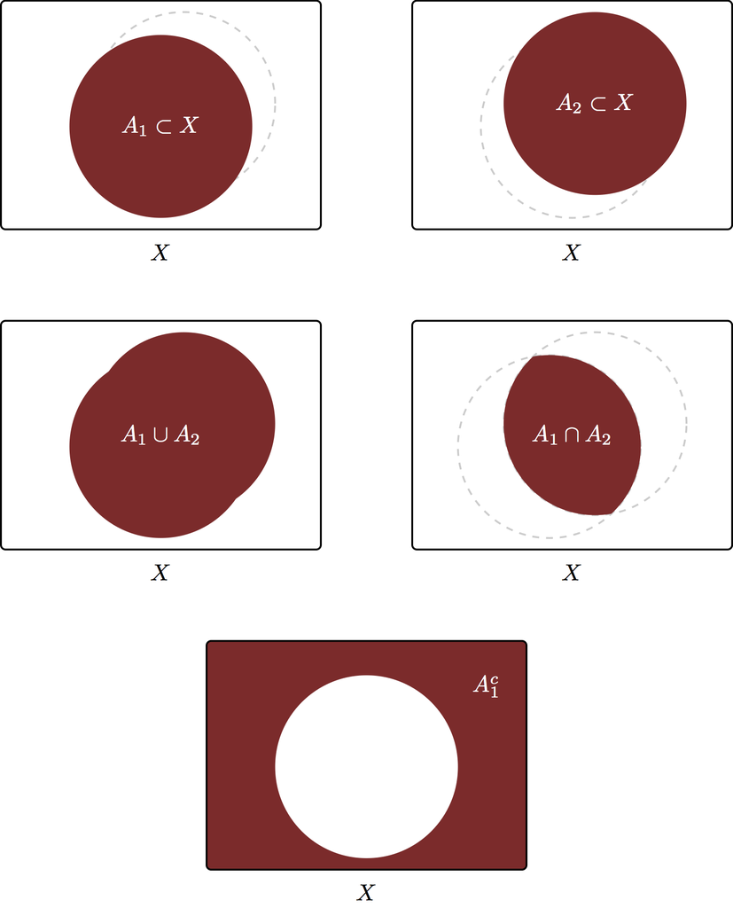

By definition the complement of the empty set is the entire space, $\emptyset^{c} = X$, and vice versa, $X^{c} = \emptyset$. The union of any set and the empty set is just that set, $A \cup \emptyset = A$, and the intersectin of any set and the empty set is just the empty set, $A \cap \emptyset = \emptyset$.

## 1.2 Functions

A *function* maps points in one space to points in another space. If a function, $f$, maps points from the space $X$ to the space $Y$ then we write
$$\begin{alignat*}{6}
f :\; &\mathcal{X}& &\rightarrow& \; &Y&
\\
&x& &\mapsto& &f(x)&.
\end{alignat*}$$

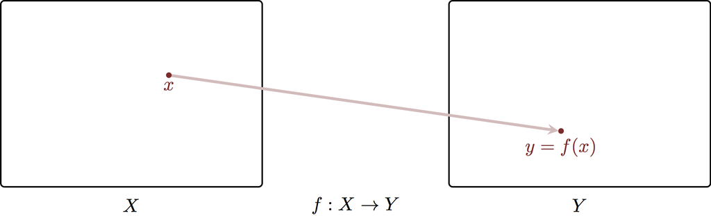

A function also induces a mapping from sets in the input space, $X$, to sets in the output space, $Y$, by applying the function to each individual point in the input set,
$$f(A) = \left\{ y \in Y \mid f^{-1}(y) \in A \right\}.$$

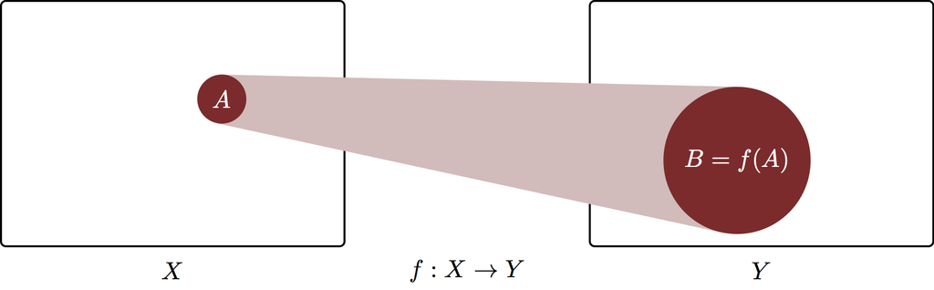

At the same time we can also map sets from the output space, $Y$, to sets in the input space, $X$, by appying the inverse of a given function,
$$f^{-1}(B) = \left\{ x \in X \mid f(x) \in B \right\}.$$
Such sets are alwasy well defined even if the function does not have a unique inverse – we just add all of the possible inverses to $f^{-1}(B)$. This set is denoted the *preimage* of the set $B$.

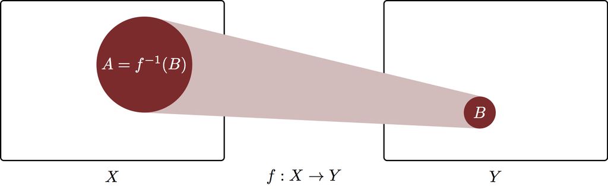

## 1.3 Sigma Algebras

The set of all sets in a space, $X$, is called the *power set*, $P(X)$. The power set is massive and, even if the space $X$ is well-behaved, the corresponding power set can often contain some less mathematically savory elements. Consequently when dealing with sets we often want to consider a restriction of the power set that removes unwanted sets.

We have to be careful, however, to apply this restriction in a self-consistent manner. In particular, we want our restriction to be closed under the three set operations so that we don’t have to worry about straying outside of our carefully manicured collection of sets. For example, if a set $A$ is in our restriction then we want its complement $A^{c}$ to also be in our restriction. If $A_{1}$ and $A_{2}$ are in our restriction then we also want the restriction to contain the union $A_{1} \cup A_{2}$ and the intersection $A_{1} \cap A_{2}$.

In fact we often will need our restrictions to be closed under a countably infinite, or *countable*, number of unions or intersections. Given a countable set of sets, $\left\{A_{1}, A_{2}, \ldots\right\}$, we want both the countable union,
$$\cup_{n = 1}^{\infty} A_{n},$$
and the countable intersection,
$$\cap_{n = 1}^{\infty} A_{n},$$
to be in the restriction.

A restricted collection of sets satisfying these closure properties is called a *$\sigma$-algebra* over the space $X$ and a choice of $\sigma$-algebra over $X$ will be denoted with a calligraphic font, $\mathcal{X}$.

Many spaces are equipped with structures that define natural $\sigma$-algebras. In particular, all of the spaces that we typically deal with in practical problems, such as the integers and the real numbers, have natural $\sigma$-algebras. Consequently we don’t have to spend any time worrying about constructing a $\sigma$-algebra in practice and the restriction of the power set to a $\sigma$-algebra has little impact on teh practical use of probability theory.

For more on these natural $\sigma$-algebas see the following optional section.

## 1.4 Extra Credit: Topology

A *topology* on a space, $X$, is a collection of sets that contains the empty set and the full space and is closed under countable unions and finite intersections. The sets in a given topology are called *open* sets and the compliment of any open set is called a *closed* set. Be warned that open and closed in the topological sence are not exact opposites – by definition the empty set and the full space are both open and closed or, shudder, *clopen*.

The topology of a space provides a formal way to define important properties like continuity. For example, the fundamental differences between discrete and continous spaces arise from their different topologies. In particular, all of the common spaces, such as the integers and the real numbers, have unique topologies from which many of their more-intuitive properties arise.

Although superficially similar, a topology is distinct from a $\sigma$-algebra. For example, the open sets are not closed under the complement operation. If we combine all of the open sets and closed sets defined by a topology, however, then we get a proper $\sigma$-algebra. $\sigma$-algebras constructed from the topology of a space are denoted *Borel $\sigma$-algebras*. Because common spaces have natural topologies they consequently also have natural Borel $\sigma$-algebras that exclude pathological sets that can cause problems.

# 2 Mathematical Logistics

Once the philosophy has been stripped away, probability theory is simply the study of an object, a probability distribution, and its transformations. Which, to be fair, is true of most of pure mathematics! Fortunately, probability distributions and their manipulations are not particularly unintuitive from this more formal perspective.

## 2.1 Probability Distributions

From a purely Mathematical perspective, probability is a positive, conserved quantity which we want to distribute across a space, $X$. We take the total amount of this conserved quantity to be 1 with arbitrary units, but the mathematical consequences are the same regardless of this scaling. From this perspective probability is simply any abstract conserved quantity – in particular it does not refer to anything inherently random or uncertain.

A *probability distribution* defines a mathematically self-consistent allocation of this conserved quantity across a space $X$. Letting $A$ be a sufficiently well-defined subset of $X$, we write $\mathbb{P}_{\pi}[A]$ as the probability assigned to $A$ by the probability distribution $\pi$. Importantly, we want this allocation to be self-consistent – the allocation to any collection of disjoint sets, $A_{n} \cap A_{m} = 0, n \ne m$, should be the same as the allocation to the union of those sets,
$$\mathbb{P}_{\pi} [ \cup_{n = 1}^{N} A_{n} ]
=
\sum_{n = 1}^{N} \mathbb{P}_{\pi} [ A_{n} ].$$
In other words, no matter how we decompose the space $X$, or any well-defined subsets of $X$, we have to conserve probability.

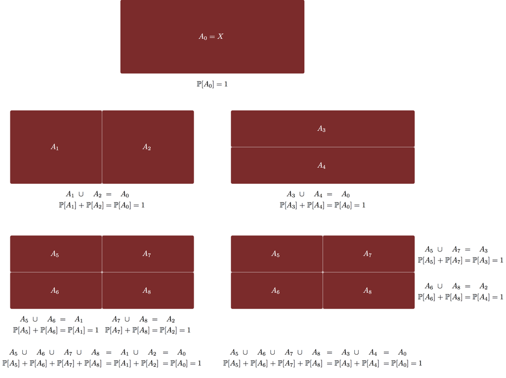

For a finite collection of sets this self-consistency property is known as *finite additivity* and would be sufficient if there were only a finite number of well-defined subsets in $X$. If we want to distribute probability across spaces with an infinite number of subsets, such as the real numbers, however, then we need to go a bit further and require self-consistency over any countable collection of disjoint sets,
$$\mathbb{P}_{\pi} [ \cup_{n = 1}^{\infty} A_{n} ]
=
\sum_{n = 1}^{\infty} \mathbb{P}_{\pi} [ A_{n} ].$$
In particular, this *countable additivity* property allows us to calculate limiting probabilities over the smaller and smaller sets that we might need to cover the area circumscribed by a smooth curve.

In addition to self-consistency we have to ensure that we assign all of the total probability in our allocation. This requires that all of the probability is allocated to the full space, $\mathbb{P}_{\pi} [X] = 1$.

These three conditions completely specify a valid probability distribution, although to be formal we have to be careful about what we mean by “well-defined” subsets of $X$. Somewhat unnervingly we cannot constuct an object that self-consistently allocates probability to *every* subset of $X$ because of some very weird, pathological subsets. Instead we have to limit our consideration to a $\sigma$-algebra, $\mathcal{X}$, that removes these odd sets.

Formally, then, probability theory is defined by *Kolmogorov’s axioms*, which we can write as:

- A probability distribution $\pi$ on a space $X$ with $\sigma$-algebra $\mathcal{X}$ is a mapping from $\mathcal{X}$ to the real numbers $[0, 1]$,
  $$\begin{alignat*}{6}
  \mathbb{P}_{\pi} :\; &\mathcal{X}& &\rightarrow& \; &[0, 1]&
  \\
  &A& &\mapsto& &\mathbb{P}_{\pi} [A]&.
  \end{alignat*}$$
- This mapping defines an lossless allocation, $\mathbb{P}_{\pi} [X] = 1$.
- This mapping defines a self-consistent allocation for any collection of disjoint sets in $\mathcal{X}$,
  $$\mathbb{P}_{\pi} [ \cup_{n = 1}^{\infty} A_{n} ]
  =
  \sum_{n = 1}^{\infty} \mathbb{P}_{\pi} [ A_{n} ],$$
  $$A_{n} \cap A_{m} = 0, \, n \ne m.$$

The more familiar rules of probabilty theory can all be derived from these axioms. For example the last self-consistency condition implies that
$$\mathbb{P}_{\pi}[A] + \mathbb{P}_{\pi}[A^{c}] = \mathbb{P}_{\pi}[X] = 1$$
or
$$\mathbb{P}_{\pi}[A] = 1 - \mathbb{P}_{\pi}[A^{c}].$$

A probability distribution is then completely specified by the *probability triplet* $(X, \mathcal{X}, \pi)$ which is often denoted more compactly as
$$x \sim \pi$$
for $x \in X$ denotes the space, $\pi$ denotes the probability distribution, and a valid $\sigma$-algebra is assumed.

## 2.2 Expectation Values

The allocation of probability across a space immediately defines a way to summarize how functions of the form $f: X \rightarrow \mathbb{R}$ behave. *Expectation values*, $\mathbb{E}_{\pi}[g]$, reduce a function to a single real number by averaging the function output, $f(x)$, weighted by the probability assigned around that point. This weighting process emphasizes how the function behaves in neighborhoods of high probability while diminishing its behavior in neighborhoods of low probability.

How exactly, however, do we formally construct these expectation values? The only expectation values that we can immediately calculate in closed form are the expectations of an *indicator function* that vanishes outside of a given set,
$$\mathbb{I}_{A} [x] =
\left\{
\begin{array}{rr}
1, & x \in A \\
0, & x \notin A
\end{array}
\right. .$$
The expectation of an indicator function is simply the weight assigned to $A$, which is just the probability allocated to that set,
$$\mathbb{E}_{\pi} [ \mathbb{I}_{A} ] \equiv \mathbb{P}_{\pi} [ A ].$$
We can then build up the expecation value of an arbitrary function with a careful approximation in terms of these indicator functions in a process known as *Lebesgue integration*. For more detail see the following optional section.

When our space is a subset of the real line, $X \subseteq \mathbb{R}$, there is a natural *embedding* of $X$ into $\mathbb{R}$,
$$\begin{alignat*}{4}
\iota :\; &X& &\rightarrow& \mathbb{R}
\\
&x& &\mapsto& x.
\end{alignat*}$$
For example this embedding would associate the points in a binary space, $\left\{0, 1\right\}$, with the corresponding zero and identify element of the real line, or the integers with the corresponding integer real numbers.

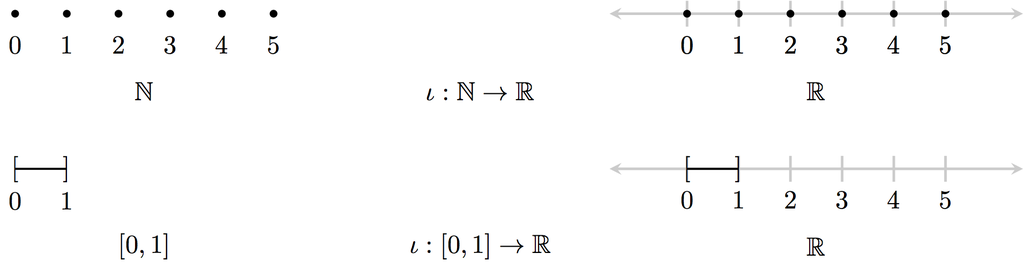

In this circumstance we define the *mean* of the probability distribution as
$$\mathbb{m}_{\pi} = \mathbb{E}_{\pi} [ \iota ],$$
which quantifies the location around which the probability distribution is focusing its allocation. Similarly we define the *variance* of the probability distribution as
$$\mathbb{V}_{\pi} = \mathbb{E}_{\pi} [ (\iota - \mathbb{m}_{\pi})^{2}],$$
which quantifies the breadth of the allocation around the mean. We will also refer to the variance of an arbitrary function as
$$\mathbb{V}_{\pi} [f] = \mathbb{E}_{\pi} [ (f - \mathbb{E}_{\pi}[f])^{2}].$$

While we can always define expectation values of a *given* function $f: X \rightarrow \mathbb{R}$, a probability distribution will not have a well-defined mean and variance unless there is some *special* function whose expectation has a particular meaning. For example, if our space is a subset of the real numbers, $X \subseteq \mathbb{R}^{N}$, then there is no special function whose expectation value defines a scalar mean. We can, however, define *component* means and variances as expectations of the *coordinate functions*, $\hat{x}_{n}: \mathbb{R}^{N} \rightarrow \mathbb{R}$, that project a point $x \in X$ onto each of the component axes. These component means and variances then provide some quantification of how the probability is allocated along each axis.

## 2.3 Extra Credit: Lebesgue Integration

As we saw in Section 2.2 only the indicator functions have immediate expectation values in terms of probabilities. In order to define more expectation values of more general functions we have to build increasingly more complex functions out of these elementary ingredients.

The countable sum of indicator functions weighted by real numbers defines a *simple function*,
$$\phi = \sum_{n} a_{n} \mathbb{I}_{A_{n}}.$$
If we require that expectation is linear over this summation then the expectation value of any simple function is given by
$$\begin{align*}
\mathbb{E}_{\pi} [ \phi ]
&=
\mathbb{E}_{\pi} \left[ \sum_{n} a_{n} \mathbb{I}_{A_{n}} \right]
\\
&=
\sum_{n} a_{n} \mathbb{E}_{\pi} [ \mathbb{I}_{A_{n}} ]
\\
&= \sum_{n} a_{n} \mathbb{P}_{\pi} [ A_{n} ].
\end{align*}$$
Because of the countable additivity of $\pi$ and the boundedness of probability, the expectation of a simple function will always be finite provided that each of the coefficients $a_{n}$ are themselves finite.

We can then use simple functions to approximate an everywhere-positive function, $g : X \rightarrow \mathbb{R}^{+}$. A simple function with only a few terms defined over only a few sets will yield a poor approximation to $g$, but as we consider more terms and more sets we can build an increasingly accurate approximation. In particular, over the space of all simple functions bounded above by $f$ we should be able to find a simple function that approximates $f$ with arbitrary accuracy.

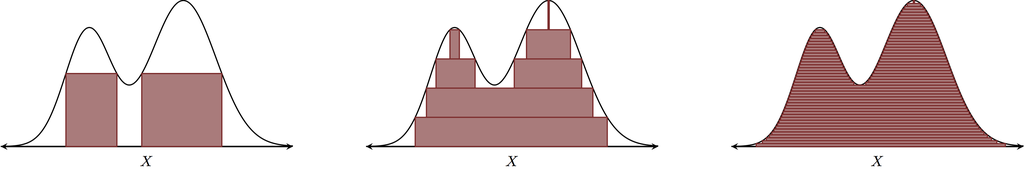

Consequently we define the expecation of an everywhere-positive function as the expectation of this approximating simple function. Because we were careful to consider only simple functions bounded by $f$ we can also define the expectation of $f$ as the largest expecation of all bounded simple functions,
$$\mathbb{E}_{\pi} [ g ] = \max_{\phi \le g} \mathbb{E}_{\pi} [ \phi ].$$

For functions that aren’t everywhere-positive we can decompose $X$ into a collection of neighborhoods where $f$ is entirely positive, $A^{+}_{n}$, and entirely negative, $A^{-}_{m}$. In those neighborhoods where $f$ is entirely positive we apply the above procedure to define
$$\mathbb{E}_{\pi} [ g \cdot \mathbb{I}_{A^{+}_{n}}],$$
while in the neighborhoods where $f$ is entirely negative we apply the above procedure on the negation of $f$ to define
$$\mathbb{E}_{\pi} [ -g \cdot \mathbb{I}_{A^{+}_{n}}].$$
. Those regions where $g$ vanishes yield zero expectation values and can be ignored. We then define the expectation value of an arbitrary function $g$ as the sum of these contributions,
$$\mathbb{E}_{\pi} [ f ] =
\sum_{n = 0}^{\infty} \mathbb{E}_{\pi} [ g \cdot \mathbb{I}_{A^{+}_{n}}]
- \sum_{m = 0}^{\infty} \mathbb{E}_{\pi} [ -g \cdot \mathbb{I}_{A^{-}_{m}}].$$

Formally this procedure is nothing more than *Lebesgue integration* originally derived from the general *measure theory* of which probability theory is a special case.

## 2.4 Measurable Transformations

Once we have defined a probability distribution on a space, $X$, and a well-behaved collection of subsets, $\mathcal{X}$, we can then consider how the probability distribution transforms when $X$ transforms. In particular, let $f: X \rightarrow Y$ be a transformation from $X$ to another space $Y$. Does this transformation also transform our probability distribution on $X$ onto a probability distribution on $Y$, and if so under what conditions?

The answer is straightforward once we have selected a $\sigma$-algebra for $Y$ as well, which we will denote $\mathcal{Y}$. In order for $f$ to induce a probability distribution on $Y$ we need the two $\sigma$-algebras to be compatible in some sense. In particular we need every subset $B \in \mathcal{Y}$ to correspond to a unique subset $f^{-1}(B) \in \mathcal{X}$. If this holds for all subsets in $\mathcal{Y}$ then we say that the transformation $f$ is *measureable* and we can define a *pushforward* distribution, $\pi_{*}$ by
$$\mathbb{P}_{\pi_{*}} [ B ] = \mathbb{P}_{\pi} [ f^{-1} (B) ].$$
In other words, if $f$ is measurable then a self-consistent allocation of probability over $X$ induces a self-consistent allocation of probability over $Y$.

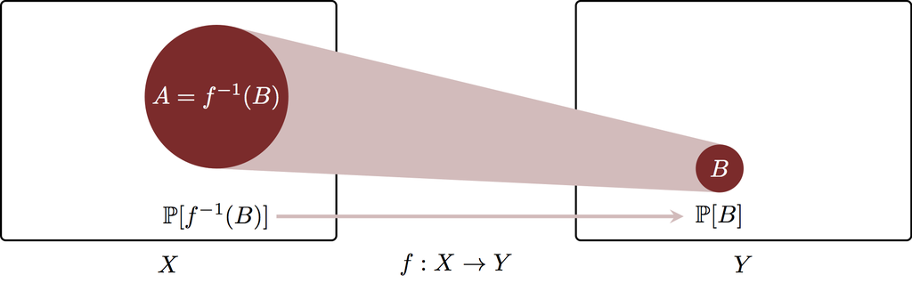

One especially important class of measurable functions are those for which $f(A) \in \mathcal{Y}$ for any $A \in \mathcal{X}$ in addition to $f^{-1}(B) \in \mathcal{X}$ for any $B \in \mathcal{Y}$. In this case $f$ transforms not only a probability distribution on $X$ into a probability distribution on $Y$ but also a probability distribution on $Y$ into a probability distribution on $X$. In this case we actually have one unique probability distribution that is just being defined over two different manifestations of the same abstract system. The two manifestations, for example, might correspond to different choices of coordinate system, or different choices of units, or different choics of language capable of the same descriptions. These *doubly measurable* transformations then serve as translations from one equivalent manifestation to another.

Measurable maps can also be used to project a probability distribution over a space onto a probability distribution over a lower-dimensional subspace. Let $\varpi: X \rightarrow Y$ be a *projection operator* that maps points in a space $X$ to points in the subspace $Y \subset X$. It turns out that in this case a $\sigma$-algebra on $Z$ naturally defines a $\sigma$-algebra on $X$ and the projection operator is measurable with respect to this choice. Consequently any *joint probability distribution* on $X$ will transform into a unique *marginal probability distribution* on $Y$. More commonly we say that we *marginalize out* the complementary subspace, $Y^{C}$.

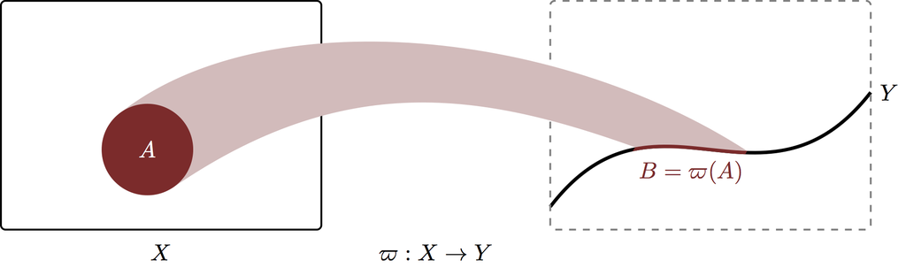

Marginalization is a bit more striaghtforward when we are dealing with a product space, $X \times Y$, which is naturally equipped with the component projection operators $\varpi_{X} : X \times Y \rightarrow X$ and $\varpi_{Y}: X \times Y \rightarrow Y$. In this case by pushing a distribution over $(X \times Y, \mathcal{X} \times \mathcal{Y})$ forwards along $\varpi_{X}$ we marginalize out $Y$ to give a probability distribution over $(X, \mathcal{X})$. At the same time by pushing that same distribution forwards along $\varpi_{Y}$ we can marginalize out $X$ to give a probability distribution over $(Y, \mathcal{Y})$.

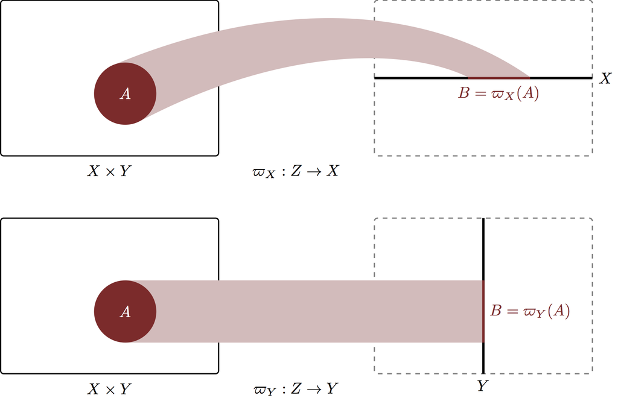

Consider, for example, the three-dimensional space, $\mathbb{R}^{3}$, where the coordinate functions serve as projection operators onto the three axes, $X$, $Y$, and $Z$. Marginalizing out $X$ transforms a probability distribution over $X \times Y \times Z$ to give a probability distribution over the two-dimensional space, $Y \times Z = \mathbb{R}^{2}$. Marginalizing out $Y$ then gives a probability distribution over the one-dimensional space, $Z = \mathbb{R}$.

## 2.5 Conditional Probability Distributions

Consider a $N$-dimensional *total space*, $X$, with the projection, $\varpi : X \rightarrow Y$, onto a $K < N$-dimensional *base space*, $Y$. By pushing a probability distribution on $X$ along the projection operator we compress all of the information about how probability is distributed along the *fibers* $\varpi^{-1} (y)$ for each $y \in Y$. In order to reconstruct the original probability distribution from a marginal probability distribution we need to specify this lost information.

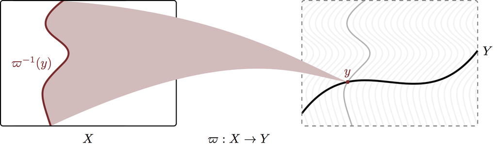

Every fiber takes the form of a $N - K$-dimensional space, $F$, and, like subspaces, these fiber spaces inherent a natural $\sigma$-algebra, $\mathcal{F}$, from the $\sigma$-algebra over the total space, $\mathcal{X}$. A *conditional probability distribution* defines a probability distribution over each fiber that varies with the base point, $y$,
$$\begin{alignat*}{6}
\mathbb{P}_{F \mid Y} :\; &\mathcal{F} \times Y& &\rightarrow& \; &[0, 1]&
\\
&(A, y)& &\mapsto& &\mathbb{P}_{F \mid Y} [A, y]&.
\end{alignat*}$$
Evaluated at any $y \in Y$ the conditional probability distribution defines a probability distribution over the corresponding fiber space, $(F, \mathcal{F})$. On the other hand, when evaluated at a given subset $A \in \mathcal{F}$ the conditonal probability distribution becomes a measurable function from $Y$ into $[0, 1]$ that quantifies how the probability of that set varies as we move from one fiber to the next.

Given a marginal distribution, $\pi_{Y}$, we can then define a probability distribution over the total space by taking an expectation value,
$$\mathbb{P}_{X} [ A ]
=
\mathbb{E}_{Y} [ \mathbb{P}_{F \mid Y} [A \cap \varpi^{-1} (y), y] ].$$
This induced distribution is consistent in the sense that if we transform it back along the projection operator we recover the marginal distribution with which we started.

This construction becomes significantly easier when we consider a product space, $X \times Y$ and the projection $\varpi: X \times Y \rightarrow Y$. In this case the fiber space is just $X$ and the conditional probability distribution becomes
$$\begin{alignat*}{6}
\mathbb{P}_{X \mid Y} :\; &\mathcal{X} \times Y& &\rightarrow& \; &[0, 1]&
\\
&(A, y)& &\mapsto& &\mathbb{P}_{X \mid Y}[A, y]&.
\end{alignat*}$$
with joint distribution
$$\mathbb{P}_{X \times Y} [ A ]
=
\mathbb{E}_{Y} [ \mathbb{P}_{X \mid Y} [A \cap X, y] ].$$

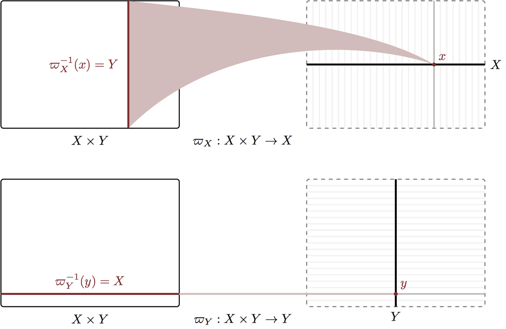

Conditional probability distributions are especially useful when we want to construct a complex probability distribution over a high-dimensonal space because we can reduce the specification of the ungainly joint probability distribution with a sequence of lower-dimensional conditional probability distributions and marginal probability distributions about which we can more easily reason. In the context of modeling an observational process, this method of construction a complicated distribution from intermediate conditional probability distributions is known as *generative* modeling. In particular, each intermediate conditional probability distribution models some fragment of the full observational process.

# 3 Representing Probability Distributions

As we saw in the prevous section, formal probability theory is simply the study of probability distributions that allocate a finite, conserved quantity across a space, the expectation values that such an allocation induces, and how the allocation behaves under transformations of the underlying space. While there is myriad complexity in the details of that study, the basics concepts are relatively straightforward.

Still, those concepts have so far been presented in the abstract without any concrete examples to provide context. Why weren’t there any examples to accompany the discussion in the previous section? Because unfortunately probability distributions cannot be explicit defined in most problems!

Recall that a probability distribution is defined as a map from the well-defined subsets in a $\sigma$-algebra to real numbers in the interval $[0, 1]$. For a $\sigma$-algebra with only a few elements we could completely specify this mapping with a lookup table, but any nontrivially large $\sigma$-algebra will simply be too large for this to be practical. What we really need is a way to define this mapping algorithmically so that we can perform necessary calculations as needed instead of exhaustively specifiying the relationships.

Fortunately most probabilistic systems admit *represenations* that faithfully recover all probabilities and expectation values on demand and hence completely specific a given probability distribution. Many represenations exploit the particular struture of $X$ to fully characterize a probability distribution with a single function, while others utilize sequences of points to construct these probabilistic computations.

One of the most common sources of misunderstanding in probability theory is the confusion of an abstract probability distribution with these representations. In an understandable desire to present concrete examples as early as possible, many introductory treatments of probability theory begin immediately with these representations only to end up muddling their relationship with the abstract mathematics that they are characterizing. Now that we have worked through the abstract definitions, however, we can introduce representations in a more principled way.

## 3.1 Probability Mass Functions

When $X$ is a discrete space any probability distribution can be represented by a *probability mass function* that assigns a probability to each atomic element of the space, $\pi : X \rightarrow [0, 1]$. From these atomic allocations we can reconstruct the probability of any subset $A \subset X$ as
$$\mathbb{P}_{\pi} [ A ] = \sum_{x \in A} \pi(x),$$
and any expectation value as
$$\mathbb{E}_{\pi} [ f ] = \sum_{x \in X} \pi(x) f(x).$$
probability mass functions also have the elegant property of transforming quite naturally along a measurable transformation of $X$,
$$\pi_{*} (y) = \sum_{x \in g^{-1}(y)} \pi(x).$$

A classic example of a probability mass function is the representation of a *Bernoulli* distribution that allocates probabilities across a binary outcome, $X = \{0, 1\}$,
$$\pi(x \mid p) = p^{x} (1 - p)^{1 - x}.$$
The mean of the Bernoulli distribution is given by the expectation of the natural embedding operator,
$$\mathbb{m}_{\pi} = \mathbb{E}_{\pi}[\iota] = p$$
with the associated variance,
$$\mathbb{V}_{\pi} = p (1 - p).$$

We also have the related *Binomial* distribution that allocates probabilities across the $N + 1$ discrete points, $X = \{0, 1, \ldots, N\}$. The probability mass function is given by
$$\pi(x \mid p, N) = p^{x} (1 - p)^{N - x}.$$
with the corresponding mean,
$$\mathbb{m}_{\pi} \mathbb{E}_{\pi}[\iota] = N p$$
and variance,
$$\mathbb{V}_{\pi} = N p (1 - p).$$
Additionally, the probability of any interval, $A = \{K_{1}, \ldots, K_{2}\}$, has the explicit form,
$$\begin{align*}
\mathbb{P}_{\pi} [A = \{K_{1}, \ldots, K_{2}\}]
&=
\sum_{k = K_{1}}^{K_{2}} \pi(k)
\\
&=
I_{1 - p} (N - K_{2}, 1 + K_{2})
- I_{1 - p} (N - K_{1} - 1, K_{1}),
\end{align*}$$
where $I_{s}(\alpha, \beta)$ is the *regularized incomplete Beta function*,
$$I_{s}(\alpha, \beta) =
\frac{ \int_{0}^{s} \mathrm{d} t \, t^{\alpha - 1} (1 - t)^{\beta - 1}}
{ \int_{0}^{1} \mathrm{d} t \, t^{\alpha - 1} (1 - t)^{\beta - 1}}.$$

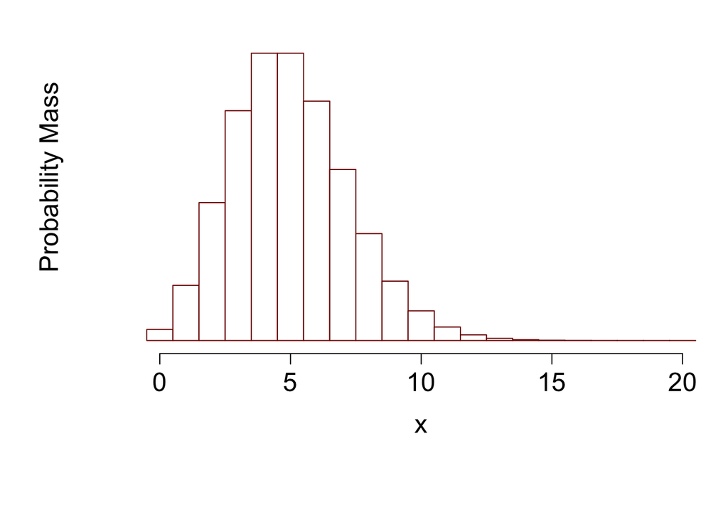

```r
c_light <- c("#DCBCBC")
c_light_highlight <- c("#C79999")
c_mid <- c("#B97C7C")
c_mid_highlight <- c("#A25050")
c_dark <- c("#8F2727")
c_dark_highlight <- c("#7C0000")

p <- hist(0, breaks=0:21-0.5, plot=FALSE)
p$counts <- dpois(0:20, 5)

par(mar = c(8, 6, 0, 0.5))
plot(p, main="", col="white", border=c_dark_highlight,
     xlab="x", yaxt='n', ylim=c(0, 0.2), ylab="Probability Mass",
     cex.lab=1.5, cex.axis=1.5, cex.main=1.5, cex.sub=1.5)
```

The mean and variance of the Poisson distribution are in fact equal,
$$\mathbb{m}_{\pi} = \mathbb{V}_{\pi} = \lambda,$$
and the probability of any interval set, $A = \{K_{1}, \ldots, K_{2}\}$, has the closed form
$$\begin{align*}
\mathbb{P}_{\pi} [A = \{K_{1}, \ldots, K_{2}\}]
&=
\sum_{k = K_{1}}^{K_{2}} \pi(k)
\\
&=
Q (\lambda, K_{2}) - Q (\lambda, K_{1} - 1),
\end{align*}$$
where $Q(\alpha, n)$ is the *regularized incomplete Gamma function*,
$$Q(\alpha, n) =
\frac{ \int_{0}^{n} \mathrm{d} t \, t^{\alpha - 1} e^{-t} }
{ \int_{0}^{\infty} \mathrm{d} t \, t^{\alpha - 1} e^{-t} }.$$

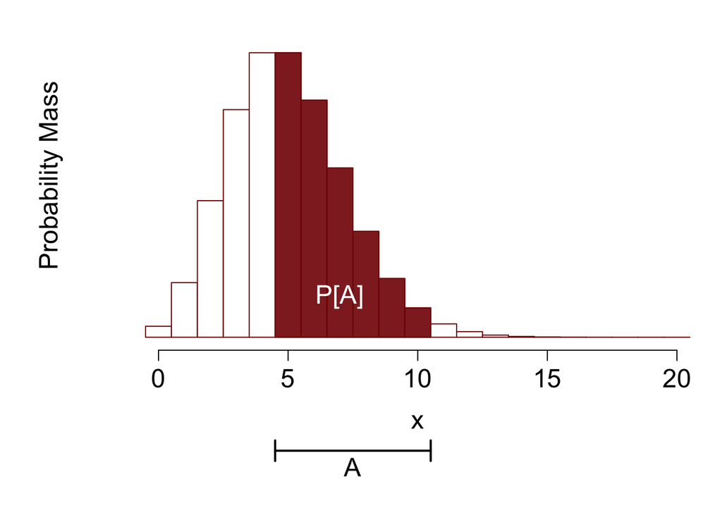

```r
p <- hist(0, breaks=0:21-0.5, plot=FALSE)
p$counts <- dpois(0:20, 5)

par(mar = c(8, 6, 0, 0.5))
plot(p, main="", col="white", border=c_dark_highlight,
     xlab="x", yaxt='n', ylim=c(0, 0.2), ylab="Probability Mass",
     cex.lab=1.5, cex.axis=1.5, cex.main=1.5, cex.sub=1.5)

p_sum <- hist(5, breaks=5:11-0.5, plot=FALSE)
p_sum$counts <- dpois(5:10, 5)

plot(p_sum, col=c_dark, border=c_dark_highlight, add=T)

par(xpd=NA)
arrows(4.5, -0.07, 10.5, -0.07, col = "black", lty = 1, lwd = 2,
       code=3, angle=90, length=0.1)
text(x=7.5, y=-0.08, labels="A", cex=1.5)
text(x=7, y=0.025, labels="P[A]", cex=1.5, col="white")
```

In `R` we can evalulate both the exhaustive sum,

```r
K1 <- 5
K2 <- 10

sum(dpois(K1:K2, 5))
```

```
[1] 0.5458114
```

and the closed form solution,

```r
ppois(K2, 5) - ppois(K1 - 1, 5)
```

```
[1] 0.5458114
```

which are indeed the same.

## 3.2 Probability Density Functions

When our space is given by the real numbers or a subset thereof, $X \subseteq \mathbb{R}^{N}$, we can no longer assign finite probability to each point $x \in X$ with a probability mass function. The problem is that in any non-atomic subset of $X$ there will be an uncountably infinite number of points and the sum of probability mass function over that subset will explode unless we assign zero probability mass to all but a countable number of points.

Consequently probability mass functions are no longer viable and instead we must utilize *probability density functions* over which we can *integrate* to give probabilities and expectations. Given a probability density function, $\pi: X \rightarrow \mathbb{R}$, we can reconstruct probabilities as
$$\mathbb{P}_{\pi} [ A ] = \int_{A} \mathrm{d} x \, \pi(x),$$
and expectation value as
$$\mathbb{E}_{\pi} [ f ] = \int_{X} \mathrm{d} x \ , \pi(x) f(x).$$

Unlike probability mass functions, probability densities don’t transform quite as naturally along a measurable transformation on $X$. Given a transformation $g : \mathbb{R}^{N} \rightarrow \mathbb{R}^{N}$, the probability density corresponding to the pushforward distribution picks up a Jacobian determinant,
$$\pi_{*} (y) = \sum_{n = 1}^{N} \pi(x_{n}(y))
\left| \frac{ \partial g}{\partial x} (x_{n}(y)) \right|^{-1},$$
where $\left\{x_{1}(y), \ldots, x_{N}(y) \right\}$ are the roots of $y = g(x)$ for a given $y$.

The most ubiquitous probability density function over the real line is the *Gaussian density*,
$$\pi(x \mid \mu, \sigma) = \frac{1}{\sqrt{2 \pi}}
\exp \left( - \frac{1}{2} \left(\frac{x - \mu}{\sigma} \right)^{2} \right).$$

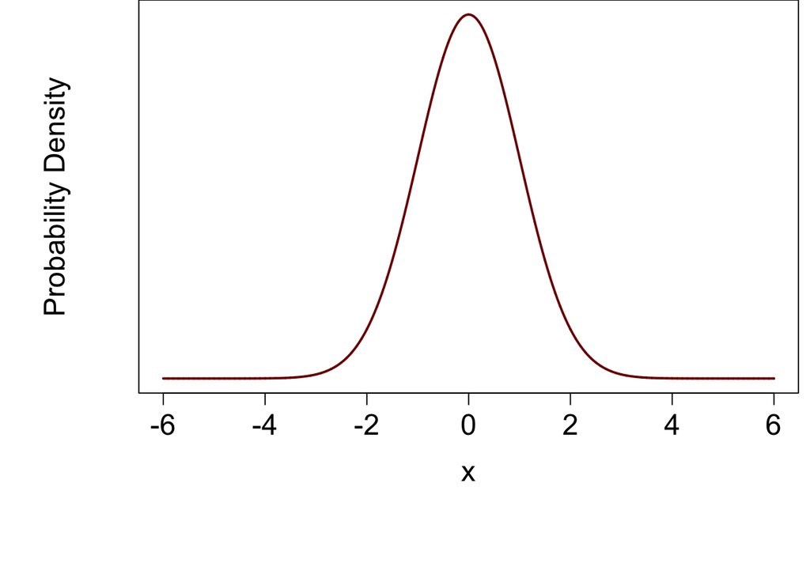

```r
x <- seq(-6, 6, 0.001)

par(mar = c(8, 6, 0, 0.5)) #b-l-t-r
plot(x, dnorm(x, 0, 1), type="l", col=c_dark_highlight, lwd=2,
     xlab="x", ylab="Probability Density",
     cex.lab=1.5, cex.axis=1.5, cex.main=1.5, cex.sub=1.5, yaxt='n')
```

Note that I have not referred to this probabilitiy density function as representing a “Gaussian probability distribution”. Under a double measurable transformation that doesn’t affect the latent probability distribution the probability density function will pick up a Jacobian determinent that can skew this bell-curved, Gaussian shape. Consequently there are no Gaussian probability distributions, just probability distributions on $X = \mathbb{R}$ that can be represented as Gaussian densities in certain manifestations of $X$.

The probability distribution represented by a Gaussian density features a mean
$$\mathbb{m}_{\pi} = \mu,$$
and a variance,
$$\mathbb{V}_{\pi} = \sigma^{2}.$$
The probability assigned to any interval $A = [a, b]$ admits a closed form,
$$\mathbb{P}_{\pi} [ A = [a, b] ] =
\frac{1}{2} \left(
\mathrm{erf} \left( \frac{1}{\sqrt{2}} \frac{b - \mu}{\sigma} \right)
- \mathrm{erf} \left( \frac{1}{\sqrt{2}} \frac{a - \mu}{\sigma} \right)
\right)$$
in terms of the *error function*,
$$\mathrm{erf}(x) = \frac{2}{\sqrt{\pi}} \int_{0}^{x} \mathrm{d} t \, e^{-t^{2}}.$$

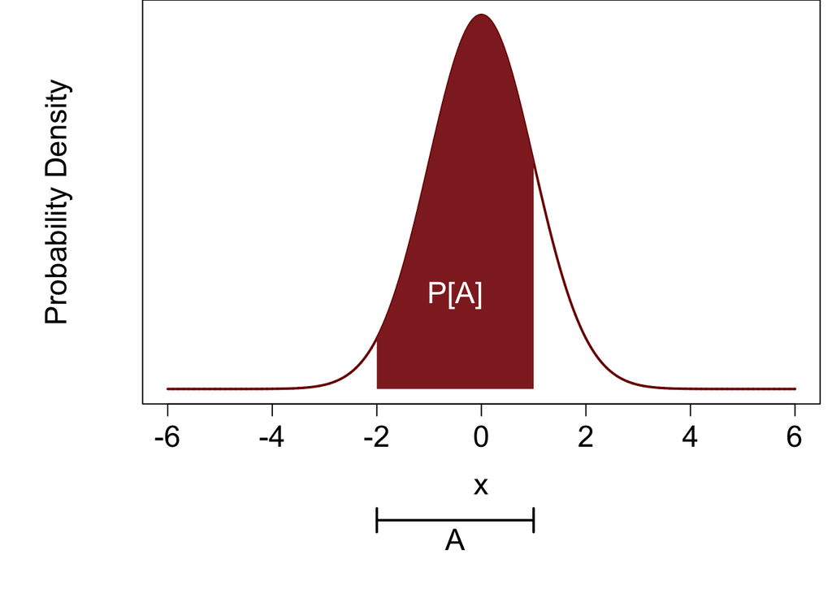

```r
x <- seq(-6, 6, 0.001)

par(mar = c(8, 6, 0, 0.5))
plot(x, dnorm(x, 0, 1), type="l", col=c_dark_highlight, lwd=2,
     xlab="x", ylab="Probability Density",
     cex.lab=1.5, cex.axis=1.5, cex.main=1.5, cex.sub=1.5, yaxt='n')

x_int <- seq(-2, 1, 0.001)
x <- c(x_int, 1, -2)
y <- c(dnorm(x_int, 0, 1), 0, 0)

polygon(x, y, col=c_dark, border=NA)

par(xpd=NA)
arrows(-2, -0.14, 1, -0.14, col = "black", lty = 1, lwd = 2,
       code=3, angle=90, length=0.1)
text(x=-0.5, y=-0.16, labels="A", cex=1.5)
text(x=-0.5, y=0.1, labels="P[A]", cex=1.5, col="white")
```

In `R` we can evaluate the closed form solution as

```r
pnorm(1, 0, 1) - pnorm(-2, 0, 1)
```

```
[1] 0.8185946
```

## 3.3 Conditional Distributions and Mixed Representations

When the fiber space, $F$, is discrete we can represent a conditional probability distribution with a conditional probability mass function,
$$\begin{alignat*}{6}
\pi_{F \mid X} :\; &F \times X& &\rightarrow& \; &[0, 1]&
\\
&(f, x)& &\mapsto& &\pi_{F \mid X} (f \mid x)&.
\end{alignat*}$$
If the base space is also discrete with marginal probabilty mass function $\pi_{X}(x)$ then a probability distribution over the total space can be represented by a probability mass function that takes the simple form
$$\pi_{Z}[f, x] = \pi_{F \mid X} ( f \mid x ) \pi_{X} (x).$$

Similarly, when the fiber space, $F$, is the real numbers then we can represent a conditional probability distribution with a conditional probability density function,
$$\begin{alignat*}{6}
\pi_{F \mid X} :\; &F \times X& &\rightarrow& \; &[0, 1]&
\\
&(f, x)& &\mapsto& &\pi_{F \mid X} (f \mid x)&.
\end{alignat*}$$
If the base space is also continous with marginal probabilty density function $\pi_{X}(x)$ then a probability distribution over the total space can be represented by a probability density function that takes the simple form
$$\pi_{Z} (f, x) = \pi_{F \mid X} ( f \mid x ) \pi_{X} (x).$$

When the fiber space is discrete and the base space is continuous, or vice versa, a probability distribution on the total space admits a *mixed representation* compromised as a product of a conditional probability mass functions and a marginal probability density function, or vice versa. For example, a discrete fiber with a continuous base space defines a probability distribution over a space that contains *both* discrete and continous properties.

Because discrete and real representations both take the form of functions, these mixed representations are straightforward to construct and utilize when computing probabilities and expectations on the total space.

## 3.4 Samples

One of the immediate difficulties with probability mass function and probability density function representations is that if a given expectation doesn’t have a closed form, as we conveniently had for the examples given above, then the computation will likely be infeasible. Exhaustive surveys of the space $X$ needed to numerically compute a summatation or integral is simply too expensive given the finite computational resources avaiable in most problems. This is especially true when we consider more complicated probability distributions over high-dimensional spaces.

An intriguing alternative to these two deterministic representations of a probability distribution uses a sequence of points in $X$ capable of *estimating* expectations with more reasonable computational demands.

Consider an arbitrary sequence of points from $X$, $S_{N} = {x_{1}, \ldots, x_{N}}$ and define the *emperical expectation* of a function $f : X \rightarrow \mathbb{R}$ as
$$\hat{f}(S_{N}) = \frac{1}{N} \sum_{n = 1}^{N} f(x_{n}).$$
A *sampling procedure* is any process that generates sequences that satsify the asymptotic property
$$\lim_{N \rightarrow \infty} \hat{f}(S_{N}) = \mathbb{E}_{\pi} [ f ],$$
for *all* functions $f$ with finite expectation values. The finite sequences generated by a sampling process are denoted *samples*. Note that by this definition any subset of such a sequence is also a sample.

As the size of a sample increases the empirical expectations converge towards the true expectation values, as well as probabilities through expectations of indicator funtions. In this way the sample procedure which is conceptually capable of generating arbitrarily long sequences provides a faithful represenation of the corresponding probability distribution. In practice we need to be able to quantify the accuracy of these estimators to understand how accurately we are representing the target probability distribution.

There is absolutely no restriction on the inner workings of a sampling procedure. Provided that it can generate sequences of arbitrary length that satisfy the asymptotic property it will be a valid sampling procedure. The procedure can be generated algorithmically and be completely deterministic given a known input configuration, generated from unknown external inputs with unpredictable outputs, or anywhere in between.

Measurable transformations are especially easy to implement with samples. If $S_{N} = {x_{1}, \ldots, x_{N}}$ is a sample from a probability distribution on $X$ then
$$S^{*}_{N} = \{ f(x_{1}), \ldots, f(x_{N}) \} = \{ y_{1}, \ldots, y_{N} \}$$
is a sample from the pushforward probability distribution along the measurable function $f : X \rightarrow Y$.

Samples also help to provide some intuition for why measurable transformations are often introduced as “random variables”. A variable is considered the output of a function with a variable, but known, input,
$$y = f(x).$$
If the input is distributed according to a probability distribution, however, then we don’t have an explicit value at which to evaluate the function, and hence define the variable,
$$x \sim \pi$$
$$y = f(x).$$
Instead we have a probability distribution over the possible variable values given by the pushforward probability distribution,
$$y \sim \pi_{*}.$$

When we represent a probability distribution with a sample, however, we do have explicit values at which we can evaluate the function. Consequently we can very loosely interpret “evaluating a random variable” as “generating samples from the corresponding pushforward distribution”.

# 4 Generating Samples

A sampling representation of a probability distribution is appealing, but how exactly do we generate samples whose empirical expectations converge to the true expectations of a given probability distribution? For sufficiently simple distributions we can generate exact samples while in general we typically have to resort to generating more subtle correlated samples.

## 4.1 Exact Samples

If each point in a sample is generated independently of the others then we say that the resulting sample is *exact*. Consequently each subset of an exact sample, including each point, is also an exact sample.

In this case the empirical expectations satisfy a *central limit theorem* which guarantees that the empirical expecations are distributed around the true expectations,
$$\hat{f}(S_{N}) \sim
\mathcal{N} \left( \mathbb{E}_{\pi} [ f ],
\sqrt{\frac{ \mathbb{V}[f] }{ N } } \right).$$
The square root of the variance in this central limit theorem is also known as the *Monte Carlo standard error*,
$$\text{MC-SE} = \sqrt{\frac{ \mathbb{V}[f] }{ N } }.$$
In practice we can estimate the variance, $\mathbb{V}[f]$, and hence the Monte Carlo standard error, by using the sample itself. The error in using a variance estimate in place of the true variance scales as $1 / N$ which is negligible compared to the dominant $1 / \sqrt{N}$ scaling of the nominal error.

Estimation expectations values using the empirical expectation of an exact samples was originally introduced as the *Monte Carlo* method, with the empirical expectations themselves known as *Monte Carlo estimators*. For a detailed history of the Monte Carlo method see @Betancourt:2018. Each state in an exact sample is also known as a *simulation*.

Exact samples can be generated for many one-dimensional distributions using a variety of highly optimized techniques. A comprehensive discussion of these techniques can be found in @Devroye:1986. These *pseudo random number generators* are initialized with an input *seed* and then can be queried repeatedly to generate the individual elements of a sample. A variety of pseudo random number generators are available in `R`, `Python`, and the Stan modeling language.

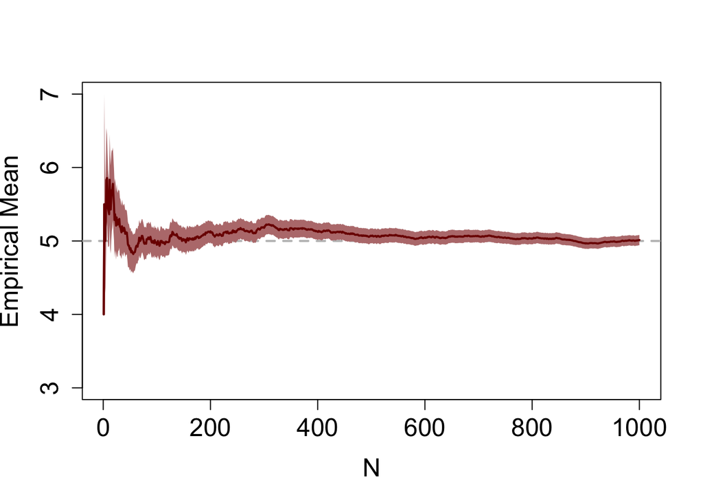

```r
N <- 1000

set.seed(13703599)
S <- rpois(N, 5)

emp_exp <- sapply(1:N, function(n) mean(S[1:n]))
emp_var <- sapply(1:N, function(n) var(S[1:n]))
mc_se <- sapply(1:N, function(n) sqrt(var(S[1:n]) / n))

plot(1:N, emp_exp, type="l", col=c_dark_highlight, lwd=2,
     ylim=c(3, 7), xlab="N", ylab="Empirical Mean",
     cex.lab=1.5, cex.axis=1.5, cex.main=1.5, cex.sub=1.5)

abline(h=5, col="grey", lty="dashed", lwd=2)
polygon(c(1:N, N:1), c(emp_exp + mc_se, rev(emp_exp - mc_se)), col=c_mid, border=NA)
lines(1:N, emp_exp, type="l", col=c_dark_highlight, lwd=2)
```

We can also estimate the probability of the set $[5, 10]$ by first evaluating the corresponding indicator function at each point in the sample and then taking the empirical average. As desired the empirical expectation converges to the true probability.

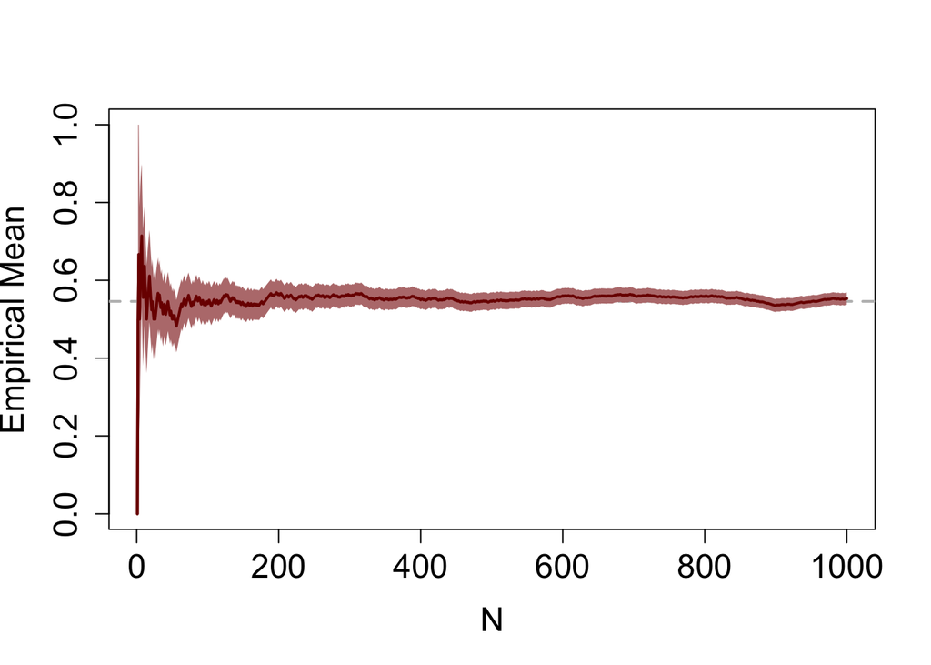

```r
S_I <- 5 <= S & S <= 10

emp_exp <- sapply(1:N, function(n) mean(S_I[1:n]))
emp_var <- sapply(1:N, function(n) var(S_I[1:n]))
mc_se <- sapply(1:N, function(n) sqrt(var(S_I[1:n]) / n))

plot(1:N, emp_exp, type="l", col=c_dark_highlight, lwd=2,
     ylim=c(0, 1), xlab="N", ylab="Empirical Mean",
     cex.lab=1.5, cex.axis=1.5, cex.main=1.5, cex.sub=1.5)

abline(h=ppois(K2, 5) - ppois(K1 - 1, 5), col="grey", lty="dashed", lwd=2)
polygon(c(1:N, N:1), c(emp_exp + mc_se, rev(emp_exp - mc_se)), col=c_mid, border=NA)
lines(1:N, emp_exp, type="l", col=c_dark_highlight, lwd=2)
```

The procedure is identical for a probability distribution represented by a Gaussian density, with the empirical mean now converging to the true value of zero.

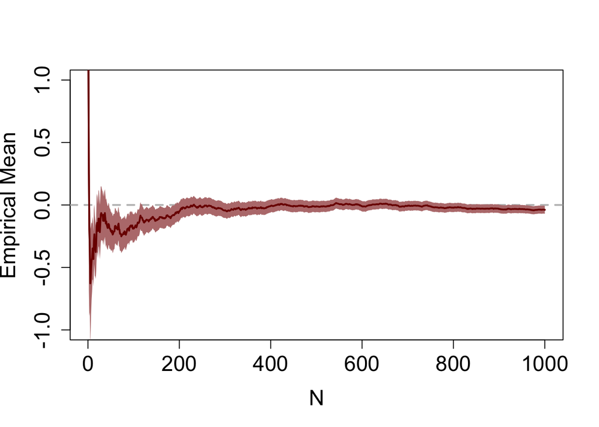

```r
N <- 1000

S <- rnorm(N, 0, 1)

emp_exp <- sapply(1:N, function(n) mean(S[1:n]))
emp_var <- sapply(1:N, function(n) var(S[1:n]))
mc_se <- sapply(1:N, function(n) sqrt(var(S[1:n]) / n))

plot(1:N, emp_exp, type="l", col=c_dark_highlight, lwd=2,
     ylim=c(-1, 1), xlab="N", ylab="Empirical Mean",
     cex.lab=1.5, cex.axis=1.5, cex.main=1.5, cex.sub=1.5)

abline(h=0, col="grey", lty="dashed", lwd=2)
polygon(c(1:N, N:1), c(emp_exp + mc_se, rev(emp_exp - mc_se)), col=c_mid, border=NA)
lines(1:N, emp_exp, type="l", col=c_dark_highlight, lwd=2)
```

We can achieve the same samples using Stan as well. Here we generate exact samples in the generated quantities block,

```r
writeLines(readLines("generate_gaussian.stan"))
```

```
generated quantities {
  real x = normal_rng(0, 1);
}
```

and configure the execution of Stan with the `fixed_param` sampler so that only the generated quantities block is run,

```r
library(rstan)
rstan_options(auto_write = TRUE)
options(mc.cores = parallel::detectCores())

fit <- stan(file='generate_gaussian.stan', iter=N, warmup=0,
            chains=1, seed=194838, algorithm="Fixed_param")
```

[output not shown]

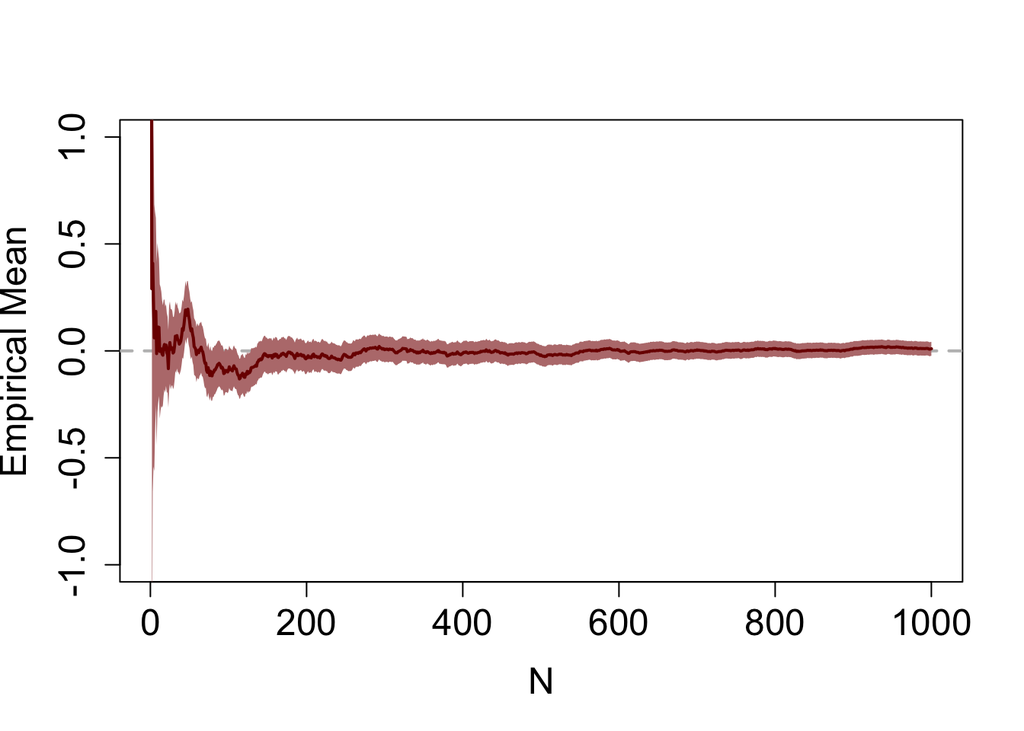

```r
S <- extract(fit)$x[]

emp_exp <- sapply(1:N, function(n) mean(S[1:n]))
emp_var <- sapply(1:N, function(n) var(S[1:n]))
mc_se <- sapply(1:N, function(n) sqrt(var(S[1:n]) / n))

plot(1:N, emp_exp, type="l", col=c_dark_highlight, lwd=2,
     ylim=c(-1, 1), xlab="N", ylab="Empirical Mean",
     cex.lab=1.5, cex.axis=1.5, cex.main=1.5, cex.sub=1.5)

abline(h=0, col="grey", lty="dashed", lwd=2)
polygon(c(1:N, N:1), c(emp_exp + mc_se, rev(emp_exp - mc_se)), col=c_mid, border=NA)
lines(1:N, emp_exp, type="l", col=c_dark_highlight, lwd=2)
```

## 4.2 Correlated Samples

For complex probability distributions, especially those on high-dimensional spaces that can’t be decomposed as a product of one-dimensional distributions, we rarely have the facilities to generate exact samples. Instead our best option is often to generate a *correlated* sample sequentially using a *Markov chain*.

A Markov chain is a series of points on a space $X$ generated by a *Markov transition*. A Markov transition is just a conditional probability distribution over the product space $X \times X$, where the first component corresponds to the current point in the Markov chain, $x_{n} \in X$, and the second component corresponds to the next point, $x_{n + 1} \in X$. The next point in the Markov chain is generated as an exact sample from this conditional probability distribution function. Given an initial point $x_{1}$ we can then generate a Markov chain by repeatedly applying the Markov transition. Under specific compatibility conditions between a Markov transition and a target probability distribution a Markov chain will yield the desired sample.

In general this *Markov chain Monte Carlo* procedure will generate Markov chain Monte Carlo estimators that converge to the true expectation values only asymptotically with no guaranatees on how they converge after only a finite number of transitions. Unlike in the Monte Carlo method, Markov chain Monte Carlo estimators don’t always satisfy a central limit theorem.

Under technical *ergodicity* conditons, however, Markov chain Monte Carlo estimators can achieve a central limit theorm of the form
$$\hat{f}(S_{N}) \sim
\mathcal{N} \left( \mathbb{E}_{\pi} [ f ],
\sqrt{\frac{ \mathbb{V}[f] }{ N_{\mathrm{eff}} } } \right).$$
Here the *effective sample size*, $N_{\mathrm{eff}}$, is a function of the correlation between the points in the Markov chain and quantifies the size of an exact sample that we would need to achieve the same estimator accuracy. As with the variance of $f$ we can estimate the correlations needed to compute the effective sample size using the sample generated by the Markov chain itself.

Stan uses the powerful *dynamic Hamiltonian Monte Carlo* method to generate Markov chains that target probability distributions defined on the real numbers. These Markov chains acheive central limit theorems for many target probability distributions and, when a central limit theorem does hold, the Markov chains typically yield very large effective sample sizes relative to the total sample size. For more details on Markov chain Monte Carlo and Hamiltonian Monte Carlo see @Betancourt:2017.

Probability distributions in Stan are specified with probability density functions defined in the Stan modeling language. A Stan program written in this language that specifies a Gaussian density is given by

```r
writeLines(readLines("fit_gaussian.stan"))
```

```
parameters {
  real x;
}

model {
  x ~ normal(0, 1);
}
```

Here the `~ normal` notation is shorthand for adding a log Gaussian density to the target log probability density function. In other words,

```
x ~ normal(0, 1)
```

is equivalent to

```
target += normal_lpdf(x | 0, 1)
```

where `target` is a global variable that stores the log of the target density function.

Given the Stan program we can readily generate our correlated sample,

```r
fit <- stan(file='fit_gaussian.stan', seed=4938483)
```

Because we are not guaranteed ideal convergence properties in Markov chain Monte Carlo we have to diligently check the diagnostics provided by Stan to verify no indications of problematic behavior.

```r
source('stan_utility.R')
check_all_diagnostics(fit)
```

```
[1] "n_eff / iter looks reasonable for all parameters"
[1] "Rhat looks reasonable for all parameters"
[1] "0 of 4000 iterations ended with a divergence (0%)"
[1] "0 of 4000 iterations saturated the maximum tree depth of 10 (0%)"
[1] "E-BFMI indicated no pathological behavior"
```

With no indications of problems we can compute the Markov chain Monte Carlo estimators for the mean,

```r
summary(fit, probs = c(), pars='x')$summary[,1:2]
```

```
       mean     se_mean
-0.01881732  0.02566346
```

consistent with the true value of $\mathbb{m}_{\pi} = 0$.

We can add measurable transformations to our model in the generated quantities block which maps the output of the Markov chain through deterministic functions. The generated quantities block in this Stan program maps the samples through the squared deviation functon, whose expectation gives the variances, and an indicator function,

```r
writeLines(readLines("fit_gaussian_plus.stan"))
```

```
parameters {
  real x;
}

model {
  x ~ normal(0, 1);
}

generated quantities {
  real sq_dev = square(x - 0); // True mean is zero
  real P = -2 < x && x < 1 ? 1 : 0;
}
```

Running our Markov chain,

```r
fit <- stan(file='fit_gaussian_plus.stan', seed=4938483)
```

and confirming no diagnostic problems,

```r
source('stan_utility.R')
check_all_diagnostics(fit)
```

```
[1] "n_eff / iter looks reasonable for all parameters"
[1] "Rhat looks reasonable for all parameters"
[1] "0 of 4000 iterations ended with a divergence (0%)"
[1] "0 of 4000 iterations saturated the maximum tree depth of 10 (0%)"
[1] "E-BFMI indicated no pathological behavior"
```

we can investigate our expectation estimates. The expectation of the squared deviation function is consistent with the true variance of one,

```r
summary(fit, probs = c(), pars='sq_dev')$summary[,1:2]
```

```
      mean    se_mean
0.98669764 0.03291296
```

and the expectation of the indicator function is consistent with the analytic value of the interval probability,

```r
summary(fit, probs = c(), pars='P')$summary[,1:2]
```

```
       mean     se_mean
0.823250000 0.008456917
```

```r
pnorm(1, 0, 1) - pnorm(-2, 0, 1)
```

```
[1] 0.8185946
```

## 4.3 Sampling From Conditional Distributions

A sample from a probability distribution on the total space defines a sample for the marginal probability distribution on the base space by evaluating the projection operator at each point in the total sample. A total sample, however, will not in general be enough informaton to generate a sample from a conditional probability distribution. The problem is that in most cases each fiber will be allocated a small or outright zero probability from the total probability distribution and no samples will fall exactly on a given fiber. Instead we have to generate samples from a conditional probability distribution by first evaluating it at a particular point in the base space and then generating samples from the corresponding probability distribution.

On the other hand, if we can generate samples from the marginal probabilty distribution and the conditional probability distribution then we can immediately generate samples from the corresponding probability distribution on the total space. We simply generate a sample from the marginal distribution and then generate samples from the conditional probability distribution evaluated at each point in the marginal sample. This *ancestral sampling* technique is particularly useful when we have constructed the total probability distribution generatively out of many simple intermediate probability distributions.

# 5 Interpretations of Probability

Now that we have a basic understanding of the abstract defintion of probability theory and some of the ways in which we can implement probabilistic calcualtions in practice we are *finally* in a place where we can consider the applications of probability theory and the corresponding philosophical interpretations of this very generic, conserved quantity that we’ve been distributing.

## 5.1 Physical Distributions

An immediate application of probability theory is modeling the conserved quantities that arise in physical models of the world, such as physical mass. Physical mass can be distributed across a solid object in myriad ways, and the exact distribution affects the how that object interacts with the world. At the same time mass flows dynamically through liquids and gasses as they interact with the surrounding environment. Time-dependent probability distributions that quantify the distribution of mass, charge, and other conserved quantities are a critical element of the corresponding mathematical physics.

## 5.2 Frequentist Statistics

Frequentist statistics uses probability theory to model the variability inherent to the observations that we make in order to learn about a particular system. The approach presumes that this variability is sufficiently simple that we can model it with a probability distribution – the more probability allocated to a neighborhood of the observation space, $Y$, the more likely we are to observe points in that neighborhood. Probability becomes a quantification of the seeming randomness of observational outcomes, although we cannot distinguish between *ontological* randomness that is inherent to the world or *epistimological* randomness that is due to our limited ability to resolve the world.

In this perspective the outcomes of the observational process is quantified with a probability distribution over the observaton space called the *true data generating process*. Observations are similarly idealized as exact samples from this probability distribution.

Although we don’t know the true data generating process, we can *model* it with a collection of mathematically convenient data generating processes, $\pi(y ; \theta)$ parameterized by the space $\theta \in \Theta$. Inferences about this model take the form of *estimators* that map observations into some selection of this model configuration space, such as points or intervals, that is considered to be consistent with the input observation. The performance of these estimators can be defined as expectations with respect to carefully chosen loss functions.

## 5.3 Bayesian Inference

Bayesian inferences uses probability theory to model any self-consistent quantification of uncertainty. This general perspective encompasses the frequentist perspective but also allows us to use probability to quantify which model configurations are most consistent with an observation. The model configuration space then becomes a conditional probability distribution, $\pi (y \mid \theta)$, and if we complement it with a *prior distribution*, $\pi(\theta)$, then we can construct the *posterior distribution* over the model configuration space,
$$\pi(\theta \mid y) \propto \pi(y \mid \theta) \, \pi(\theta),$$
which quantifies how consistent the model configurations are with prior information and observed data. Inferential queries about the observation process itself are then answered by expectation values of various functions.

# 6 Conclusion

Probability theory is a powerful tool for both modeling and making inferences from the world around us. Often that power is undercut by confusion in exactly what objects and computations probability theory defines and how we can implement those computations in practice. By very carefully untangling the abstract theory from the practical implementations and the many applications we can take a more principled introduction through the theory and ensure that we exploit it as much as possible.

# 7 Original Computing Environment

```r
writeLines(readLines(file.path(Sys.getenv("HOME"), ".R/Makevars")))
```

```
CXXFLAGS=-O3 -mtune=native -march=native -Wno-unused-variable -Wno-unused-function -Wno-macro-redefined

CC=clang
CXX=clang++ -arch x86_64 -ftemplate-depth-256
```

# 8 References